# Pathway 2: Multi-Solid Global Assembly

## 6. Compare with Analytical Solution

The `RWGAnalytical` class provides closed-form S- and Z-parameters for a rectangular waveguide. Note that the total length is the sum of the two components: $L = 0.1 + 0.1 = 0.2$ m.

```python
from cavsim3d.analytical.rectangular_waveguide import RWGAnalytical

# Create analytical model with the total length (sum of both components)
analytical = RWGAnalytical(
    a=0.1, L=0.2,
    freq_range=(fom_config['fmin'], fom_config['fmax'])
)

# Plot comparison: FOM vs Analytical
which = [['1(1)1(1)'], ['1(1)2(1)']]

fig, axs = plt.subplot_mosaic(
    [[1, 2], [3, 4]], figsize=(10, 8), layout='constrained'
)

for idx, wh in enumerate(which):
    # Magnitude
    analytical.plot_s(wh, ax=axs[idx + 1])
    concat.plot_s(wh, ax=axs[idx + 1])
    # Phase
    analytical.plot_s(wh, plot_type='phase', ax=axs[idx + 3])
    concat.plot_s(wh, plot_type='phase', ax=axs[idx + 3])

fig.suptitle('Concat vs Analytical — S-Parameters', fontsize=14)
```

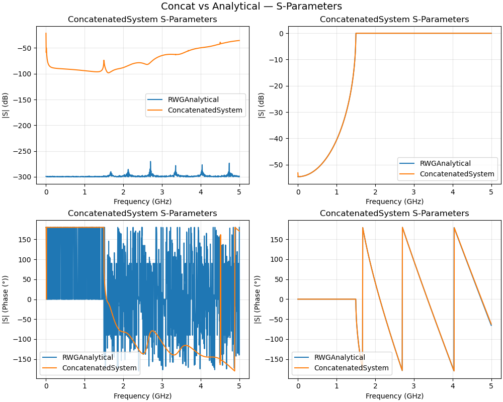

## Summary

In this tutorial we:

1. Created an `EMProject` and a multi-component assembly with automatic alignment
2. Built and meshed the fused assembly
3. Configured and ran the Frequency Domain Solver via the `config` dictionary
4. Plotted compound S-parameter magnitude and phase using `proj.fds.foms`
5. Validated results against the analytical solution

This pathway is ideal for small assemblies. For larger systems, see:

- Pathway 3: FOM Concatenation
- Pathway 4: ROM Concatenation